# Regression Analysis

# Ceo Compensation

## Load Data

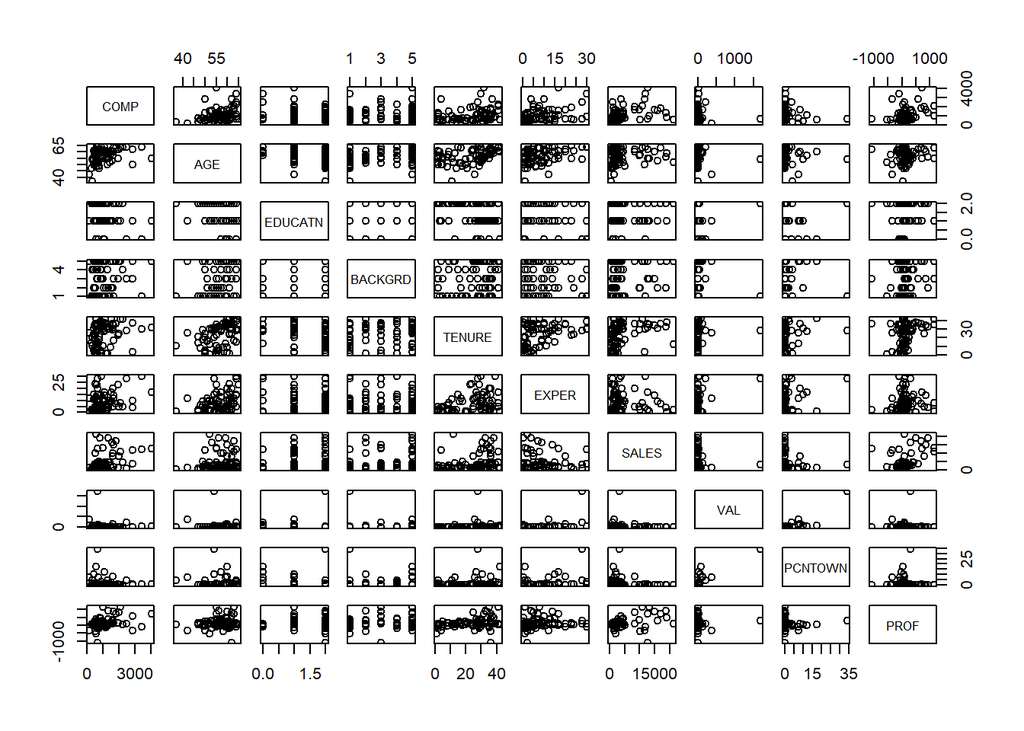

```r
library(readr)

ceocomp <- read_csv("C:/Users/adity/Downloads/ceocomp.csv")

set.seed(20887979)

my.dat = ceocomp[sample(nrow(ceocomp),75),]

plot(my.dat)
```

Conducting a preliminary examination of the scatter plots, we observe a somewhat positive correlation among variables such as tenure, age, experience, sales, and profit. This alignment is intuitively logical, as compensation naturally ought to increase when these factors experience a corresponding upward trend.

## Constructing a Linear Model

```r
my.dat1 <- subset(my.dat, my.dat$PROF>=0)
my.dat1
```

```
## # A tibble: 56 x 10
##     COMP   AGE EDUCATN BACKGRD TENURE EXPER SALES   VAL PCNTOWN  PROF
##    <dbl> <dbl>   <dbl>   <dbl>  <dbl> <dbl> <dbl> <dbl>   <dbl> <dbl>
##  1   893    60       2       4     36  15    4444   2      0.04   417
##  2   597    57       2       4     27  13    2686   1.4    0.03   377
##  3   541    51       2       2     17  12     862   1      0.1    113
##  4  1571    53       1       2     31   9   16115   4.2    0.09   301
##  5   576    48       2       1      8   6    1199   0.3    0.02   134
##  6   600    52       2       5     12   2   21351   4.2    0.26   101
##  7  1652    60       2       3     34  14   14949  11.5    0.06   856
##  8  1671    63       2       1     17  12    1967   5.5    0.2    143
##  9   809    59       1       5     38   0.5 19196   0.4    0.01   505
## 10  1630    60       1       5     36  20    8331 132.     8.21    82
## # ... with 46 more rows
```

```r
my.dat1$BACKGRD <- as.factor(my.dat1$BACKGRD)
y <- my.dat1$COMP
x1 <- my.dat1$AGE
x2 <- my.dat1$EDUCATN
x3 <- my.dat1$BACKGRD
x4 <- my.dat1$TENURE
x5 <- my.dat1$EXPER
x6 <- my.dat1$SALES
x7 <- my.dat1$VAL
x8 <- my.dat1$PCNTOWN
x9 <- my.dat1$PROF

my.dat1lm = lm(y~x1+x2+x3+x4+x5+x6+x7+x8+x9)

summary(my.dat1lm)
```

```
##
## Call:
## lm(formula = y ~ x1 + x2 + x3 + x4 + x5 + x6 + x7 + x8 + x9)
##
## Residuals:
##     Min      1Q  Median      3Q     Max
## -996.03 -263.77  -62.86  219.39 1996.11
##
## Coefficients:
##               Estimate Std. Error t value Pr(>|t|)
## (Intercept)  247.29719 1130.54159   0.219   0.8279
## x1            15.27692   20.31651   0.752   0.4562
## x2          -298.49213  187.16650  -1.595   0.1181
## x32         -110.99238  293.50631  -0.378   0.7072
## x33            1.38975  273.89514   0.005   0.9960
## x34         -298.55371  304.79300  -0.980   0.3328
## x35          -30.93286  296.02385  -0.104   0.9173
## x4             2.55585    9.51381   0.269   0.7895
## x5            27.70670   13.67947   2.025   0.0491 *
## x6             0.01378    0.02204   0.625   0.5351
## x7             0.53309    0.94530   0.564   0.5757
## x8           -50.78519   39.62798  -1.282   0.2069
## x9             0.77423    0.42290   1.831   0.0741 .
## ---
## Signif. codes:  0 '***' 0.001 '**' 0.01 '*' 0.05 '.' 0.1 ' ' 1
##
## Residual standard error: 598.3 on 43 degrees of freedom
## Multiple R-squared:  0.4541, Adjusted R-squared:  0.3018
## F-statistic: 2.981 on 12 and 43 DF,  p-value: 0.004175
```

We can check model adequacy by assessing the R-Squared Value. Our model only accounts for 45% of the variation suggesting we have an inadequate model. We will create a reduced model without the Background Variate and perform an Anova Test to confirm our hypothesis.

```r
my.dat2lm <- lm(y~x1+x2+x4+x5+x6+x7+x8+x9)
anova(my.dat2lm,my.dat1lm)
```

```
## Analysis of Variance Table
##
## Model 1: y ~ x1 + x2 + x4 + x5 + x6 + x7 + x8 + x9
## Model 2: y ~ x1 + x2 + x3 + x4 + x5 + x6 + x7 + x8 + x9
##   Res.Df      RSS Df Sum of Sq      F Pr(>F)
## 1     47 15848689
## 2     43 15390418  4    458271 0.3201  0.863
```

Now since the p-values are above the significance level of 0.05 the variate background and compensation may be correlated causing an increase in variance. Thus we will use the reduced model going forward.

## Assessing the Reduced Model

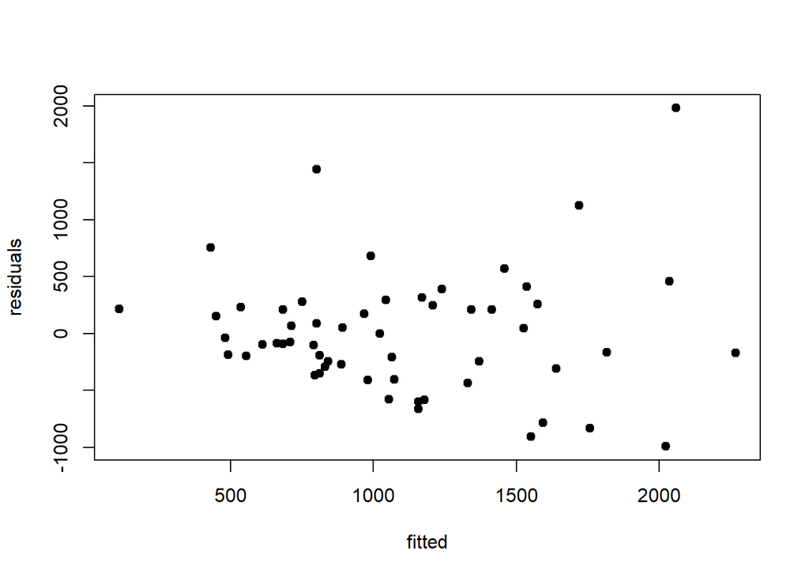

```r
plot(fitted(my.dat2lm), residuals(my.dat2lm), pch=19,xlab='fitted',ylab='residuals')
```

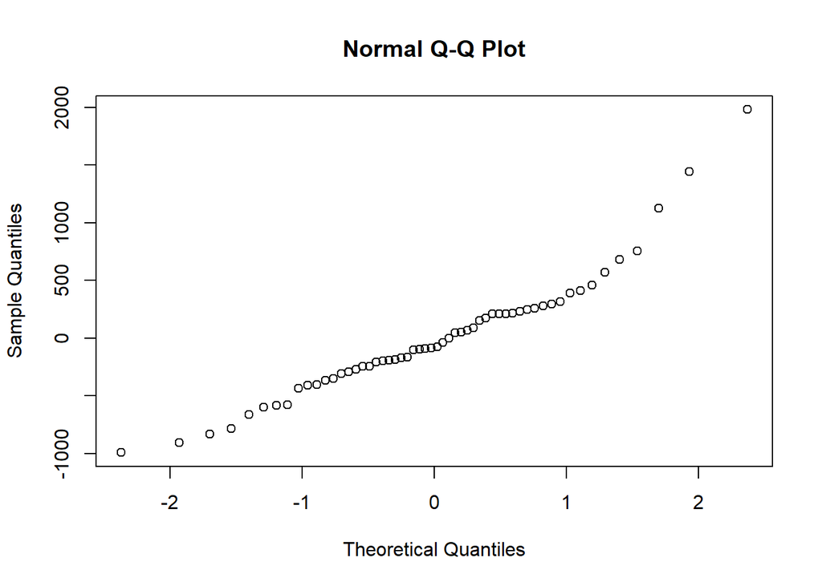

```r
qqnorm(residuals(my.dat2lm))
```

Based on the residual vs fitted plot it is evident that there is non-constant variation of errors hence making the model inadequate. Looking at the QQ plot we can see that the assumption of normal errors is not met since the line is not straight.

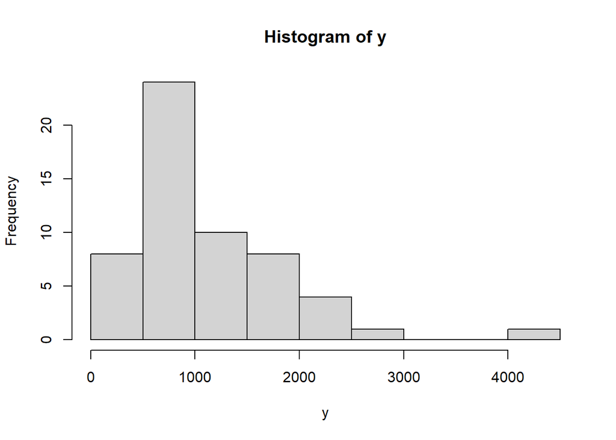

```r
hist(y)
```

Creating a histogram for y we can see the right skewness in the distribution suggests that a log transformation might help to normalize the response.

```r
newy <- log(y)

my.dat3lm <- lm(newy~x1+x2+x4+x5+x6+x7+x8+x9)

summary(my.dat3lm)
```

```
##
## Call:
## lm(formula = newy ~ x1 + x2 + x4 + x5 + x6 + x7 + x8 + x9)
##
## Residuals:
##      Min       1Q   Median       3Q      Max
## -0.77883 -0.34690 -0.06428  0.30669  0.97523
##
## Coefficients:
##               Estimate Std. Error t value Pr(>|t|)
## (Intercept)  5.572e+00  7.821e-01   7.124 5.29e-09 ***
## x1           2.188e-02  1.351e-02   1.619   0.1121
## x2          -2.425e-01  1.305e-01  -1.858   0.0694 .
## x4           1.412e-03  7.137e-03   0.198   0.8440
## x5           1.874e-02  1.002e-02   1.870   0.0677 .
## x6           1.893e-05  1.522e-05   1.243   0.2199
## x7           6.469e-04  6.850e-04   0.944   0.3499
## x8          -4.592e-02  2.908e-02  -1.579   0.1209
## x9           5.539e-04  3.100e-04   1.786   0.0805 .
## ---
## Signif. codes:  0 '***' 0.001 '**' 0.01 '*' 0.05 '.' 0.1 ' ' 1
##
## Residual standard error: 0.4538 on 47 degrees of freedom
## Multiple R-squared:  0.4875, Adjusted R-squared:  0.4003
## F-statistic: 5.588 on 8 and 47 DF,  p-value: 5.49e-05
```

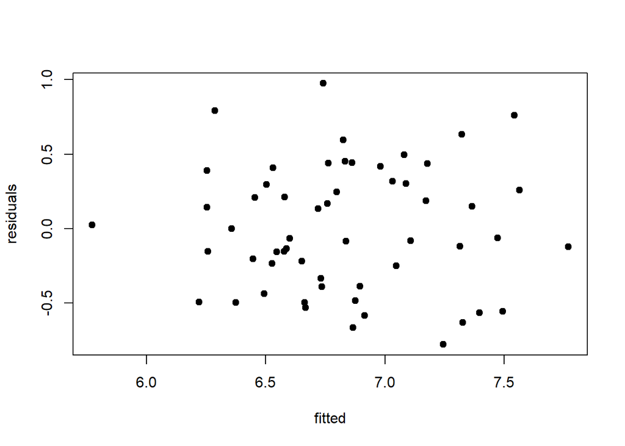

```r
plot(fitted(my.dat3lm), residuals(my.dat3lm), pch=19,xlab='fitted',ylab='residuals')
```

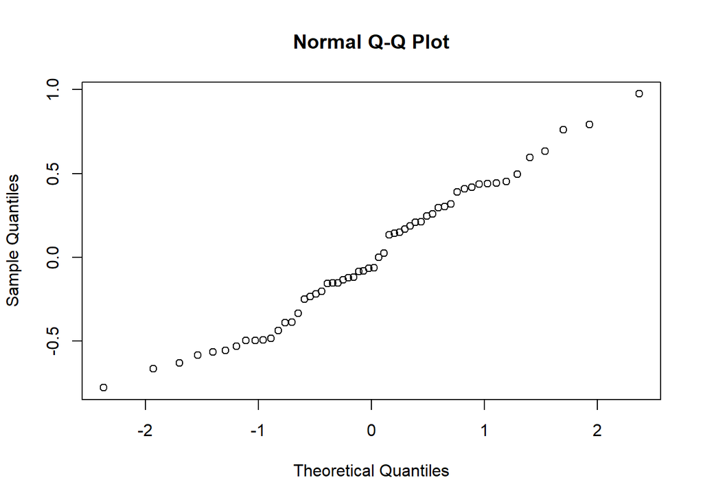

```r
qqnorm(residuals(my.dat3lm))
```

We can see the overall fit of the model got better since the Multiple R-Squared value increased by approximately .05. Looking at the individual paramters it is evident that the estimates and the standard errors got significantly smaller after the transformation was applied.

```r
newx6 <- log(x6)
newx7 <- log(x7)
newx8 <- log(x8)
newx9 <- log(x9)

my.dat4lm <- lm(newy~x1+x2+x4+x5+newx6+newx7+newx8+newx9)

summary(my.dat4lm)
```

```
##
## Call:
## lm(formula = newy ~ x1 + x2 + x4 + x5 + newx6 + newx7 + newx8 +
##     newx9)
##
## Residuals:
##     Min      1Q  Median      3Q     Max
## -0.6531 -0.2982  0.0383  0.2490  0.8283
##
## Coefficients:
##              Estimate Std. Error t value Pr(>|t|)
## (Intercept)  4.118751   0.846238   4.867 1.32e-05 ***
## x1           0.027403   0.012098   2.265  0.02816 *
## x2          -0.274638   0.117070  -2.346  0.02325 *
## x4          -0.011762   0.006809  -1.727  0.09067 .
## x5           0.004251   0.009940   0.428  0.67086
## newx6        0.154024   0.077428   1.989  0.05251 .
## newx7        0.340529   0.100352   3.393  0.00141 **
## newx8       -0.299073   0.099206  -3.015  0.00414 **
## newx9       -0.079808   0.087094  -0.916  0.36417
## ---
## Signif. codes:  0 '***' 0.001 '**' 0.01 '*' 0.05 '.' 0.1 ' ' 1
##
## Residual standard error: 0.4125 on 47 degrees of freedom
## Multiple R-squared:  0.5766, Adjusted R-squared:  0.5046
## F-statistic: 8.002 on 8 and 47 DF,  p-value: 9.794e-07
```

The Multiple R Squared is now 0.5766 which is 9% better than our previous model. Thus we will now look to improve our model through backward selection using a threshold of a=0.15.

## Improving Model Accuracy Through Backward Selection

```r
my.dat5lm <- lm(newy~x1+x2+x4+newx6+newx7+newx8+newx9)

summary(my.dat5lm)
```

```
##
## Call:
## lm(formula = newy ~ x1 + x2 + x4 + newx6 + newx7 + newx8 + newx9)
##
## Residuals:
##      Min       1Q   Median       3Q      Max
## -0.66905 -0.29619  0.01694  0.23850  0.88004
##
## Coefficients:
##              Estimate Std. Error t value Pr(>|t|)
## (Intercept)  4.086082   0.835578   4.890 1.17e-05 ***
## x1           0.029035   0.011383   2.551 0.013994 *
## x2          -0.273860   0.116056  -2.360 0.022403 *
## x4          -0.011914   0.006742  -1.767 0.083530 .
## newx6        0.148255   0.075592   1.961 0.055664 .
## newx7        0.353057   0.095161   3.710 0.000538 ***
## newx8       -0.300665   0.098289  -3.059 0.003627 **
## newx9       -0.078525   0.086298  -0.910 0.367405
## ---
## Signif. codes:  0 '***' 0.001 '**' 0.01 '*' 0.05 '.' 0.1 ' ' 1
##
## Residual standard error: 0.4089 on 48 degrees of freedom
## Multiple R-squared:  0.575,  Adjusted R-squared:  0.513
## F-statistic: 9.277 on 7 and 48 DF,  p-value: 3.298e-07
```

```r
my.dat6lm <- lm(newy~x1+x2+x4+newx6+newx7+newx8)

summary(my.dat6lm)
```

```
##
## Call:
## lm(formula = newy ~ x1 + x2 + x4 + newx6 + newx7 + newx8)
##
## Residuals:
##      Min       1Q   Median       3Q      Max
## -0.63095 -0.30813  0.01916  0.20236  0.84117
##
## Coefficients:
##              Estimate Std. Error t value Pr(>|t|)
## (Intercept)  3.911724   0.811882   4.818 1.44e-05 ***
## x1           0.029748   0.011336   2.624 0.011548 *
## x2          -0.255376   0.114063  -2.239 0.029737 *
## x4          -0.012163   0.006724  -1.809 0.076619 .
## newx6        0.134467   0.073927   1.819 0.075039 .
## newx7        0.305126   0.079113   3.857 0.000335 ***
## newx8       -0.243282   0.075258  -3.233 0.002196 **
## ---
## Signif. codes:  0 '***' 0.001 '**' 0.01 '*' 0.05 '.' 0.1 ' ' 1
##
## Residual standard error: 0.4082 on 49 degrees of freedom
## Multiple R-squared:  0.5676, Adjusted R-squared:  0.5147
## F-statistic: 10.72 on 6 and 49 DF,  p-value: 1.383e-07
```

We first removed Experience (x5) from our model since it corresponds with the highest p value. Next we removed profit (x9) from our model. Thus we have now arrived at a suitable model since all the p-values are below the threshold. We can see that the preferred model based on the Adjusted R-Squared value is 51.47% which means the model provides moderate explanatory power in determining compensation.

## Anova Test

```r
anova(my.dat6lm, my.dat4lm)
```

```
## Analysis of Variance Table
##
## Model 1: newy ~ x1 + x2 + x4 + newx6 + newx7 + newx8
## Model 2: newy ~ x1 + x2 + x4 + x5 + newx6 + newx7 + newx8 + newx9
##   Res.Df    RSS Df Sum of Sq      F Pr(>F)
## 1     49 8.1654
## 2     47 7.9958  2   0.16957 0.4984 0.6107
```

Since the p-value from this test is significantly greater than 0.05 we can confirm the reduced model is preferred.

## Checking Model Assumptions

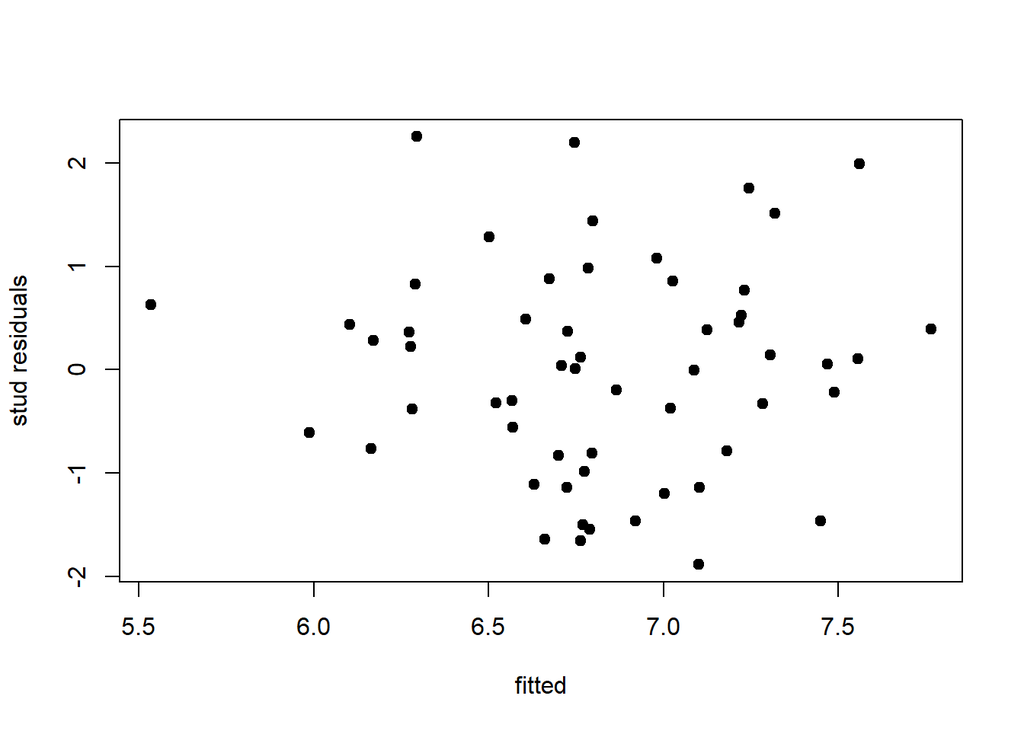

```r
library(MASS)
stud_resid <- studres(my.dat6lm)

plot(fitted(my.dat4lm),stud_resid,pch=19,xlab='fitted',ylab='stud residuals')
```

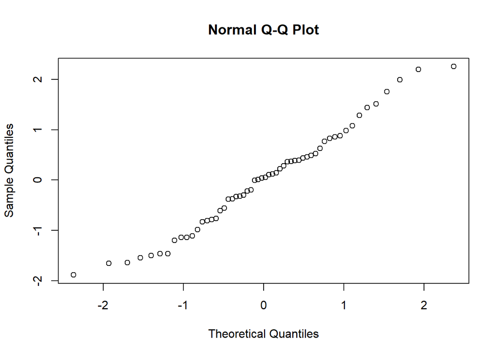

```r
qqnorm(stud_resid)
```

In terms of the model assumptions, the model is adequate since the studentized residuals vs the fitted values have a random scatter and the qqplot is linear.